# Тестовое задание на соискание должности исследователя "Белка Диджитал"

## Описание задачи

**Задача 1** Построить математическую модель стоимости жилья в зависимости от параметров этого жилья.

В качестве источника исходных данных предлагается использовать данные сайта магнитогорской недвижимости www.citystar.ru.

**Задача 2** На основе данных собранных в задании 1 разбить исходную выборку на кластеры методами кластерного анализа. Цель задания определить район продажи квартиры на основе данных о ценах, площадях и количестве комнат. Сравнить полученный результат с реальным расположением квартир по районам. В качестве района рассматривать Ленинский, Орджоникидзевский, Правобережный, Орджоникидзевский (Левый берег) и Ленинский (левый берег).

# Задача 1

## Загрузка данных

```python
import warnings
warnings.simplefilter(action='ignore', category=FutureWarning)

import pandas as pd
import numpy as np

from sklearn.impute import KNNImputer, SimpleImputer
from sklearn.model_selection import train_test_split
from sklearn.metrics import mean_squared_error
from sklearn.tree import DecisionTreeRegressor
from sklearn.ensemble import RandomForestRegressor
from sklearn.linear_model import LinearRegression
from sklearn.compose import ColumnTransformer
from sklearn.preprocessing import StandardScaler, OneHotEncoder
from sklearn.pipeline import Pipeline
from sklearn.model_selection import GridSearchCV
from sklearn.cluster import KMeans

from catboost import CatBoostRegressor
from phik import resources, report
import matplotlib.pyplot as plt

import seaborn as sns

import joblib
import os.path

import requests
from bs4 import BeautifulSoup as bs
```

```python
#Функция парсинга сайта www.citystar.ru
def Site_parsing():

    URL_base = "http://citystar.ru/detal.htm?d=43\
            &nm=%CE%E1%FA%FF%E2%EB%E5%ED\
            %E8%FF%20%20%CF%F0%EE%E4%E0%E\
            C%20%EA%E2%E0%F0%F2%E8%F0%F3%20%\
            E2%20%E3.%20%CC%E0%E3%ED%E8%F2%EE%E3%EE%F0%F1%EA%E5"

    FILE_NAME = "data_flats.csv"
    rows = []

    for page in range(1, 10):
        URL = URL_base + "&pN=" + str(page)

        r = requests.get(URL)
        print("Статус получения страницы №" + str(page) + ": ", r.status_code)
        r.encoding = 'cp1251'
        text = r.text

        soup1 = bs(text, "html.parser")
        apartments = soup1.find_all('tr', class_='tbb')

        #Как не странно, но сайт всегда отвечает кодом 200, даже если данные на запрашиваемой странице нет
        #Поэтому организуем проверку на наличие данных в ответе сервера
        if len(apartments) == 0:
            break;

        for aprt in apartments:
            fields = []
            for element in aprt.find_all('td'):
                fields.append(element.text)

            columns = [
                'photo',
                'date',
                'type_flat',
                'region',
                'address',
                'floor',
                'total_area',
                'living_area',
                'kitchen_area',
                'note',
                'price',
                'telephone',
                'agency',
                'email'
            ]

            rows.append(dict(zip(columns, fields)))

    df = pd.DataFrame(rows)

    print("Количество полученных объявлений о продажи квартир:", len(df))
    df.to_csv(FILE_NAME)

    return df
```

```python
if os.path.exists('data_flats.csv'):
    data = pd.read_csv('data_flats.csv')
else:
    data = Site_parsing()
```

### Обзор данных

```python
data.info()
```

```
<class 'pandas.core.frame.DataFrame'>
RangeIndex: 567 entries, 0 to 566
Data columns (total 15 columns):
 #   Column        Non-Null Count  Dtype
---  ------        --------------  -----
 0   Unnamed: 0    567 non-null    int64
 1   photo         567 non-null    object
 2   date          555 non-null    object
 3   type_flat     555 non-null    object
 4   region        324 non-null    object
 5   address       555 non-null    object
 6   floor         555 non-null    object
 7   total_area    555 non-null    float64
 8   living_area   555 non-null    float64
 9   kitchen_area  555 non-null    float64
 10  note          549 non-null    object
 11  price         555 non-null    float64
 12  telephone     555 non-null    object
 13  agency        433 non-null    object
 14  email         413 non-null    object
dtypes: float64(4), int64(1), object(10)
memory usage: 66.6+ KB
```

```python
data.describe()
```

|  | Unnamed: 0 | total_area | living_area | kitchen_area | price |
| --- | --- | --- | --- | --- | --- |
| count | 567.000000 | 555.000000 | 555.000000 | 555.000000 | 555.000000 |
| mean | 283.000000 | 56.192486 | 32.818631 | 8.731658 | 3615.232432 |
| std | 163.823075 | 26.698001 | 17.767302 | 3.829694 | 1571.194425 |
| min | 0.000000 | 14.100000 | 0.000000 | 0.000000 | 0.000000 |
| 25% | 141.500000 | 42.450000 | 20.000000 | 6.000000 | 2595.000000 |
| 50% | 283.000000 | 52.000000 | 31.100000 | 8.000000 | 3400.000000 |
| 75% | 424.500000 | 65.200000 | 43.450000 | 10.000000 | 4400.000000 |
| max | 566.000000 | 318.000000 | 150.000000 | 30.000000 | 9990.000000 |

```python
data.sample(5)
```

|  | Unnamed: 0 | photo | date | type_flat | region | address | floor | total_area | living_area | kitchen_area | note | price | telephone | agency | email |
| --- | --- | --- | --- | --- | --- | --- | --- | --- | --- | --- | --- | --- | --- | --- | --- |
| 460 | 460 | \n\n\n\n\n\n | 06.0913:25\n\n\n\n | Трехкомнатная | Орджоникидзевский | Карла Маркса 233 | 8/10 | 60.0 | 45.0 | 8.0 | Звоните!!! на сообщения ответить не всегда ест... | 3700.0 | 79049757094 ... Андрей Михайлович | Ипотечный сервис | egupov153@mail.ru |
| 241 | 241 | \n\n\n\n\n\n | 23.0809:48\n\n\n\n | Трехкомнатная | NaN | Зеленый Лог 27 | 6/9 | 69.0 | 43.0 | 12.0 | id:10928. \r\nПродам раздельную трехкомнатную ... | 5650.0 | 79048132941 ... Константин Смирнов | РиоЛюкс | smirnov.riolux@gmail.com |
| 22 | 22 | \n\n\n\n\n\n | 08.0910:57\n\n\n\n | Трехкомнатная | Правобережный район | ул имени газеты Правда 31 | 5/5 | 56.1 | 41.0 | 7.0 | id:5806. \r\nВнимание!\r\nВ продаже трёхкомнат... | 3950.0 | 79517815787 ... Елена Устинова | Рио-Люкс | ustinova.riolux@gmail.com |
| 197 | 197 | \n\n\r\n \r\n ... | 31.0808:43\n\n\n\n | Трехкомнатная | NaN | ул Ворошилова 23/1 | 5/9 | 58.0 | 35.0 | 7.0 | id:26126. \r\nПродается 3 квартира в 9 этажном... | 4350.0 | 79823645334 ... Галина Лоскутова | РиоЛюкс | loskutova.riolux@gmail.com |
| 262 | 262 | \n\n\n\n\n\n | 13.0808:20\n\n\n\n | Трехкомнатная | NaN | Мичурина 28 | 5/5 | 60.0 | 45.0 | 6.0 | id:6147. \r\nПродам трехкомнатную квартиру в х... | 1450.0 | 79097472729 ... Канат Бикмурзин | РиоЛюкс | kanat174.riolux@gmail.com |

```python
display(pd.DataFrame(round(data.isna().mean()*100,1)).style.background_gradient('coolwarm'))
```

|  | 0 |
| --- | --- |
| Unnamed: 0 | 0.000000 |
| photo | 0.000000 |
| date | 2.100000 |
| type_flat | 2.100000 |
| region | 42.900000 |
| address | 2.100000 |
| floor | 2.100000 |
| total_area | 2.100000 |
| living_area | 2.100000 |
| kitchen_area | 2.100000 |
| note | 3.200000 |
| price | 2.100000 |
| telephone | 2.100000 |
| agency | 23.600000 |
| email | 27.200000 |

**Выводы по обзору данных**

- Видны пропуски данных, потребуется предобработка;
- При предобработки данных необходимо исключить незначимые столбцы ('Unnamed: 0', 'photo', 'date' и пр.);
- Из столбца 'floor' нужно получить этаж квартиры и этажность дома;
- Из столбца 'type_flat' нужно получить количество комнат в квартире.

### Предобработка данных

Исключим незначимые столбцы:

```python
data = data.drop(['Unnamed: 0', 'photo', 'date', 'address', 'note', 'telephone', 'agency', 'email'], axis=1)
```

Посмотрим на квартиры с пропущенными значениями цены:

```python
data[data['price'].isna()]
```

|  | type_flat | region | floor | total_area | living_area | kitchen_area | price |
| --- | --- | --- | --- | --- | --- | --- | --- |
| 2 | NaN | NaN | NaN | NaN | NaN | NaN | NaN |
| 11 | NaN | NaN | NaN | NaN | NaN | NaN | NaN |
| 104 | NaN | NaN | NaN | NaN | NaN | NaN | NaN |
| 113 | NaN | NaN | NaN | NaN | NaN | NaN | NaN |
| 206 | NaN | NaN | NaN | NaN | NaN | NaN | NaN |
| 215 | NaN | NaN | NaN | NaN | NaN | NaN | NaN |
| 308 | NaN | NaN | NaN | NaN | NaN | NaN | NaN |
| 317 | NaN | NaN | NaN | NaN | NaN | NaN | NaN |
| 410 | NaN | NaN | NaN | NaN | NaN | NaN | NaN |
| 419 | NaN | NaN | NaN | NaN | NaN | NaN | NaN |
| 512 | NaN | NaN | NaN | NaN | NaN | NaN | NaN |
| 521 | NaN | NaN | NaN | NaN | NaN | NaN | NaN |

Данные по квартирам полностью пропущенные, исключим:

```python
data = data.dropna(subset=['price'])
```

**Обработка *floor*:**

Выделим этаж квартиры и этажность дома.

```python
data['floor'].unique()
```

```
array(['5/9', '1/3', '4/5', '7/10', '6/9', '9/9', '8/9', '2/5', '8/10',
       '1/10', '3/5', '5/5', '1/1', '1/5', '3/4', '2/14', '1/4', '10/11',
       '3/3', '4/10', '2/3', '3/9', '5/14', '7/14', '9/10', '4/13',
       '5/16', '1/2', '4/16', '7/9', '1/9', '2/10', '2/4', '2/2', '5/10',
       '7/8', '4/4', '2/16', '13/14', '1/13', '7/16', '4/6', '14/14',
       '6/10', '3/14', '10/10', '2/9', '4/9', '3/10', '11/14', '7/12',
       '9/14', '6/8', '6/16', '6/14', '5/12', '9/17', '13/16', '11/12',
       '-1/1'], dtype=object)
```

Извлекем этаж квартиры и этажность дома:

```python
data['floors_total'] = pd.to_numeric(data['floor'].str.split("/", expand=True)[1]).abs()
data['floor'] = pd.to_numeric(data['floor'].str.split("/", expand=True)[0]).abs()
```

```python
data['floor'].unique()
```

```
array([ 5,  1,  4,  7,  6,  9,  8,  2,  3, 10, 13, 14, 11], dtype=int64)
```

```python
data['floors_total'].unique()
```

```
array([ 9,  3,  5, 10,  1,  4, 14, 11, 13, 16,  2,  8,  6, 12, 17],
      dtype=int64)
```

**Обработка *region*:**

В столбце 'region' много пропусков, более 40%. Исключать такое количество нельзя. Поэтому заменим пропуски константой "Unknow".

```python
data['region'] = data['region'].fillna(value='Unknow')
```

```python
data['region'].unique()
```

```
array(['Правобережный', 'Ленинский', 'Unknow', 'Орджоникидзевский',
       'Правобережный район', 'Орджоникидзевский (левый берег)',
       'правобережный', 'Ленинский (Левый берег)', 'орджоникидзевский'],
      dtype=object)
```

Исключим неявные дубликаты и приведем значения к единому стандарту:

```python
data.loc[data['region'] == "Правобережный район", 'region'] = "Правобережный"
data.loc[data['region'] == "правобережный", 'region'] = "Правобережный"
data.loc[data['region'] == "орджоникидзевский", 'region'] = "Орджоникидзевский"
data.loc[data['region'] == "Ленинский (Левый берег)", 'region'] = "Ленинский (левый берег)"
```

```python
data['region'].unique()
```

```
array(['Правобережный', 'Ленинский', 'Unknow', 'Орджоникидзевский',
       'Орджоникидзевский (левый берег)', 'Ленинский (левый берег)'],
      dtype=object)
```

**Обработка type_flat**

```python
data['type_flat'].unique()
```

```
array(['Двухкомнатная ', 'Однокомнатная ', 'Трехкомнатная ',
       'Четырехкомнатная ', 'Двухкомнатная гребенка',
       'Трехкомнатная нестандартная', 'Трехкомнатная старой планировки',
       'Многокомнатная ', 'Трехкомнатная брежневка',
       'Трехкомнатная свердловский вариант', 'Двухкомнатная хрущевка',
       'Двухкомнатная старой планировки', 'Четырехкомнатная полусмежная',
       'Однокомнатная малосемейка', 'Трехкомнатная улучшенная',
       'Двухкомнатная улучшенная', 'Однокомнатная брежневка',
       'Двухкомнатная брежневка', 'Двухкомнатная сталинский вариант',
       'Трехкомнатная ленинградский проект',
       'Двухкомнатная нестандартная', 'Однокомнатная хрущевка', ' ',
       'Двухкомнатная раздельная', 'Однокомнатная свердловский вариант',
       'Однокомнатная улучшенная', 'Четырехкомнатная нестандартная',
       'Четырехкомнатная брежневка', 'Однокомнатная полустудия',
       'Однокомнатная нестандартная', 'Трехкомнатная брежневка ',
       'Однокомнатная старой планировки', 'Двухкомнатная Улучшенная ',
       'Трехкомнатная раздельная', 'Четырехкомнатная распашонка',
       'Двухкомнатная ленинградский проект',
       'Трехкомнатная сталинский вариант', 'Многокомнатная нестандартная',
       'Четырехкомнатная раздельная', 'Трехкомнатная хрущевка',
       'Двухкомнатная хрущевка '], dtype=object)
```

Исключим не заполненые данные:

```python
data.loc[data['type_flat'] == ' ', 'type_flat'].count()
```

```
5
```

```python
data = data[data['type_flat'] != ' ']
```

Выделим из столбца признак количество комнат в квартире.

```python
data.groupby('type_flat')['total_area'].count()
```

```
type_flat
Двухкомнатная                         150
Двухкомнатная Улучшенная                1
Двухкомнатная брежневка                12
Двухкомнатная гребенка                  5
Двухкомнатная ленинградский проект      1
Двухкомнатная нестандартная             2
Двухкомнатная раздельная                6
Двухкомнатная сталинский вариант        4
Двухкомнатная старой планировки         9
Двухкомнатная улучшенная                7
Двухкомнатная хрущевка                  7
Двухкомнатная хрущевка                  1
Многокомнатная                          6
Многокомнатная нестандартная            1
Однокомнатная                         121
Однокомнатная брежневка                 3
Однокомнатная малосемейка               5
Однокомнатная нестандартная             3
Однокомнатная полустудия                1
Однокомнатная свердловский вариант      2
Однокомнатная старой планировки         1
Однокомнатная улучшенная                3
Однокомнатная хрущевка                  1
Трехкомнатная                         115
Трехкомнатная брежневка                 7
Трехкомнатная брежневка                 1
Трехкомнатная ленинградский проект      3
Трехкомнатная нестандартная            15
Трехкомнатная раздельная                2
Трехкомнатная свердловский вариант      4
Трехкомнатная сталинский вариант        2
Трехкомнатная старой планировки        12
Трехкомнатная улучшенная               11
Трехкомнатная хрущевка                  1
Четырехкомнатная                       19
Четырехкомнатная брежневка              1
Четырехкомнатная нестандартная          1
Четырехкомнатная полусмежная            2
Четырехкомнатная раздельная             1
Четырехкомнатная распашонка             1
Name: total_area, dtype: int64
```

```python
list_type_flat =\
    {'Однокомнатная': 1, 'Двухкомнатная': 2, 'Трехкомнатная': 3, 'Четырехкомнатная': 4, 'Многокомнатная': 4}

for key, value in list_type_flat.items():
    index = data['type_flat'].str.contains(key, regex=False)
    data.loc[index, 'rooms'] = value

data = data.drop('type_flat', axis=1)
```

```python
data.head()
```

|  | region | floor | total_area | living_area | kitchen_area | price | floors_total | rooms |
| --- | --- | --- | --- | --- | --- | --- | --- | --- |
| 0 | Правобережный | 5 | 53.0 | 35.0 | 8.0 | 4100.0 | 9 | 2.0 |
| 1 | Ленинский | 1 | 26.0 | 13.0 | 7.0 | 1000.0 | 3 | 1.0 |
| 3 | Unknow | 1 | 67.9 | 47.7 | 6.0 | 4199.0 | 3 | 3.0 |
| 4 | Unknow | 4 | 61.0 | 45.0 | 7.0 | 3500.0 | 5 | 4.0 |
| 5 | Орджоникидзевский | 7 | 62.6 | 38.0 | 12.0 | 6100.0 | 10 | 2.0 |

```python
data['rooms'].info()
```

```
<class 'pandas.core.series.Series'>
Index: 550 entries, 0 to 566
Series name: rooms
Non-Null Count  Dtype
--------------  -----
550 non-null    float64
dtypes: float64(1)
memory usage: 8.6 KB
```

Приведем данные к целочисленному типу

```python
data['rooms'] = data['rooms'].astype('int', errors='ignore')
```

**Проверим диапазоны числовых признаков**

Проверим диапазон общей площади квартир:

```python
data['total_area'].min()
```

```
14.1
```

```python
data['total_area'].max()
```

```
318.0
```

Проверим диапазон жилой площади:

```python
data['living_area'].min()
```

```
0.0
```

```python
data['living_area'].max()
```

```
150.0
```

Жилая площадь не должна быть равной 0. Видимо не всегда пользователи заполняют это поле.

Если пропуски заполнять средним/медианным значением группы, то получатся случаи когда жилая площадь равна общей площади. Поэтому обработаем это следующим образом. Вычислим коэффициент равный отношению средней жилой площади к средней общей площади квартиры для каждого типа квартиры (однокомнатной, двухкомнатной и т.д.). Использую рассчитанный коффициент и общую площадь квартиры вычислим жилую площадь.

```python
data[data['living_area'] == 0].sample(5)
```

|  | region | floor | total_area | living_area | kitchen_area | price | floors_total | rooms |
| --- | --- | --- | --- | --- | --- | --- | --- | --- |
| 559 | Unknow | 1 | 47.3 | 0.0 | 10.0 | 3000.0 | 5 | 2 |
| 301 | Ленинский | 3 | 43.2 | 0.0 | 6.0 | 2200.0 | 10 | 2 |
| 247 | Орджоникидзевский | 2 | 102.2 | 0.0 | 16.0 | 7300.0 | 10 | 3 |
| 12 | Unknow | 8 | 64.8 | 0.0 | 14.0 | 4790.0 | 10 | 2 |
| 227 | Орджоникидзевский | 1 | 52.8 | 0.0 | 9.0 | 3800.0 | 13 | 2 |

```python
list_rooms = data.loc[data['living_area'] == 0, 'rooms'].unique()
for rooms in list_rooms:
    coeff = (
        data.loc[data['rooms'] == rooms, 'living_area'].mean() /
        data.loc[data['rooms'] == rooms, 'total_area'].mean()
    )
    data.loc[(data['rooms'] == rooms) & (data['living_area'] == 0), 'living_area'] =\
    round(data.loc[(data['rooms'] == rooms) & (data['living_area'] == 0), 'total_area'] * coeff, 1)
```

```python
data['living_area'].min()
```

```
8.2
```

```python
data['kitchen_area'].min()
```

```
0.0
```

```python
data['kitchen_area'].max()
```

```
30.0
```

Обработаем аналогично пропускам столбца 'living_area'

```python
data[data['kitchen_area'] == 0]
```

|  | region | floor | total_area | living_area | kitchen_area | price | floors_total | rooms |
| --- | --- | --- | --- | --- | --- | --- | --- | --- |
| 24 | Unknow | 9 | 65.2 | 41.0 | 0.0 | 4250.0 | 9 | 3 |
| 42 | Unknow | 3 | 17.5 | 8.2 | 0.0 | 2460.0 | 4 | 1 |
| 126 | Unknow | 9 | 65.2 | 41.0 | 0.0 | 4250.0 | 9 | 3 |
| 144 | Unknow | 3 | 17.5 | 8.2 | 0.0 | 2460.0 | 4 | 1 |
| 290 | Unknow | 2 | 14.1 | 12.0 | 0.0 | 1270.0 | 2 | 1 |
| 348 | Unknow | 1 | 23.0 | 13.0 | 0.0 | 2150.0 | 2 | 1 |
| 398 | Unknow | 9 | 65.2 | 41.0 | 0.0 | 4250.0 | 9 | 3 |
| 403 | Unknow | 1 | 63.4 | 39.9 | 0.0 | 530.0 | 2 | 3 |
| 472 | Unknow | 3 | 16.5 | 16.5 | 0.0 | 2330.0 | 5 | 1 |
| 509 | Unknow | 5 | 61.5 | 38.7 | 0.0 | 3700.0 | 5 | 3 |
| 514 | Unknow | 2 | 23.0 | 17.0 | 0.0 | 1580.0 | 4 | 1 |
| 537 | Unknow | 1 | 19.0 | 16.5 | 0.0 | 1450.0 | 2 | 1 |

```python
list_rooms = data.loc[data['kitchen_area'] == 0, 'rooms'].unique()
for rooms in list_rooms:
    coeff = (
        data.loc[data['rooms'] == rooms, 'kitchen_area'].mean() /
        data.loc[data['rooms'] == rooms, 'total_area'].mean()
    )
    data.loc[(data['rooms'] == rooms) & (data['kitchen_area'] == 0), 'kitchen_area'] =\
    round(data.loc[(data['rooms'] == rooms) & (data['kitchen_area'] == 0), 'total_area'] * coeff, 1)
```

```python
data['price'].min()
```

```
0.0
```

Квартиры с нулевым значение цены исключим

```python
data.loc[data['price'] == 0, 'price'].count()
```

```
2
```

```python
data = data[data['price'] > 0]
```

```python
data['price'].max()
```

```
9990.0
```

```python
data.head()
```

|  | region | floor | total_area | living_area | kitchen_area | price | floors_total | rooms |
| --- | --- | --- | --- | --- | --- | --- | --- | --- |
| 0 | Правобережный | 5 | 53.0 | 35.0 | 8.0 | 4100.0 | 9 | 2 |
| 1 | Ленинский | 1 | 26.0 | 13.0 | 7.0 | 1000.0 | 3 | 1 |
| 3 | Unknow | 1 | 67.9 | 47.7 | 6.0 | 4199.0 | 3 | 3 |
| 4 | Unknow | 4 | 61.0 | 45.0 | 7.0 | 3500.0 | 5 | 4 |
| 5 | Орджоникидзевский | 7 | 62.6 | 38.0 | 12.0 | 6100.0 | 10 | 2 |

**Проверим и исключим полные дубликаты**

```python
data.duplicated().sum()
```

```
113
```

```python
data = data.drop_duplicates().reset_index(drop=True)
```

**Посмотрим результат преобработки данных**

```python
data.info()
```

```
<class 'pandas.core.frame.DataFrame'>
RangeIndex: 435 entries, 0 to 434
Data columns (total 8 columns):
 #   Column        Non-Null Count  Dtype
---  ------        --------------  -----
 0   region        435 non-null    object
 1   floor         435 non-null    int64
 2   total_area    435 non-null    float64
 3   living_area   435 non-null    float64
 4   kitchen_area  435 non-null    float64
 5   price         435 non-null    float64
 6   floors_total  435 non-null    int64
 7   rooms         435 non-null    int32
dtypes: float64(4), int32(1), int64(2), object(1)
memory usage: 25.6+ KB
```

```python
display(pd.DataFrame(round(data.isna().mean()*100,1)).style.background_gradient('coolwarm'))
```

|  | 0 |
| --- | --- |
| region | 0.000000 |
| floor | 0.000000 |
| total_area | 0.000000 |
| living_area | 0.000000 |
| kitchen_area | 0.000000 |
| price | 0.000000 |
| floors_total | 0.000000 |
| rooms | 0.000000 |

**Выводы предобработки данных**

В процессе предобработки были выполнены шаги:

- исключены незначимые столбцы в данных;
- из столбца 'floor' получены этаж квартиры и этажность дома;
- Из столбца 'type_flat' получен признак количество комнат в квартире;
- Исключили явные и неявные дубликаты.

### Исследовательский анализ данных

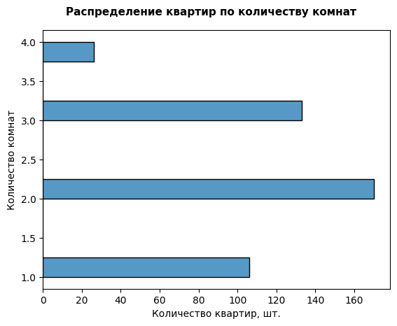

```python
fig = plt.figure()
ax = fig.add_subplot()
fig.suptitle('Распределение квартир по количеству комнат', fontsize=11, fontweight='bold', y=0.95)
sns.histplot(data=data, y='rooms')
ax.set(xlabel='Количество квартир, шт.', ylabel='Количество комнат')
plt.show();
```

Из графика видно, что двухкомнатные квартиры имеют большее распространение.

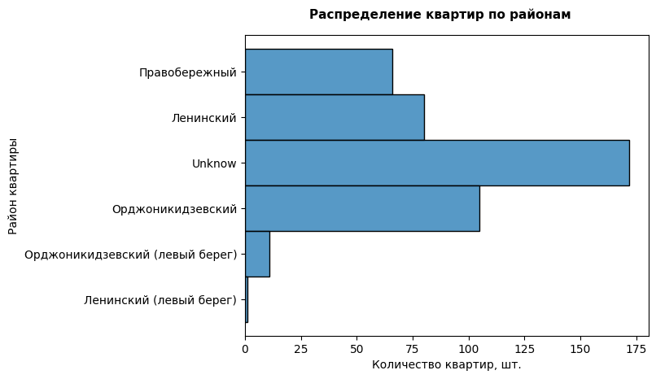

```python
fig = plt.figure()
ax = fig.add_subplot()
fig.suptitle('Распределение квартир по районам', fontsize=11, fontweight='bold', y=0.95)
sns.histplot(data=data, y='region')
ax.set(xlabel='Количество квартир, шт.', ylabel='Район квартиры')
plt.show();
```

Видно как сильно выделяются квартиры с не заданным районом (Unknow). Для большей возможности автоматизации анализа, разработчикам сайта следует сделать поле района обязательным.

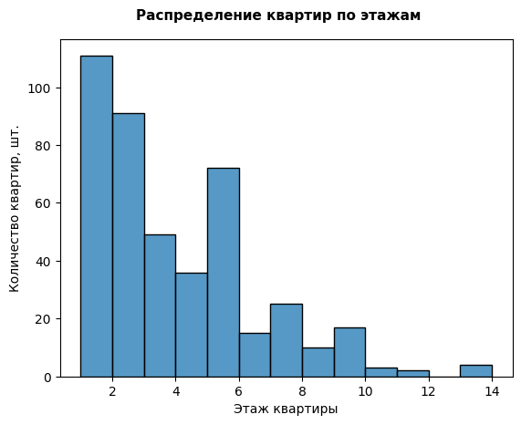

```python
fig = plt.figure()
ax = fig.add_subplot()
fig.suptitle('Распределение квартир по этажам', fontsize=11, fontweight='bold', y=0.95)
sns.histplot(data=data, x='floor')
ax.set(xlabel='Этаж квартиры', ylabel='Количество квартир, шт.')
plt.show();
```

Объявления о продажи квартир располагающихся на первом этаже предобладают над остальными.

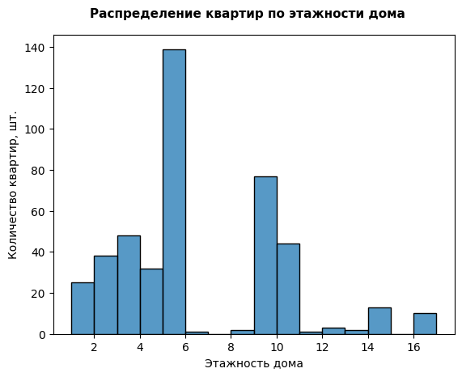

```python
fig = plt.figure()
ax = fig.add_subplot()
fig.suptitle('Распределение квартир по этажности дома', fontsize=11, fontweight='bold', y=0.95)
sns.histplot(data=data, x='floors_total', binwidth=1)
ax.set(xlabel='Этажность дома', ylabel='Количество квартир, шт.')
plt.show();
```

Большинство квартир продаются в 5 этажных домах.

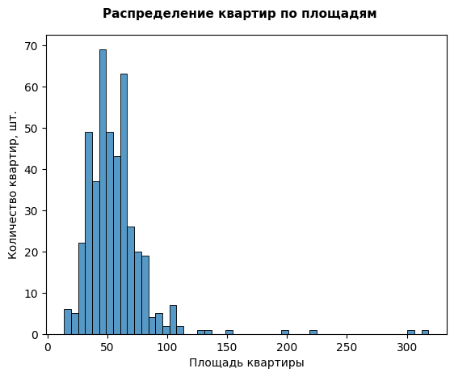

```python
fig = plt.figure()
ax = fig.add_subplot()
fig.suptitle('Распределение квартир по площадям', fontsize=11, fontweight='bold', y=0.95)
sns.histplot(data=data, x='total_area')
ax.set(xlabel='Площадь квартиры', ylabel='Количество квартир, шт.')
plt.show();
```

Среднее значение общей площади квартир представленных в выборке находится около 50 кв.м.